# The Data

## Comparison to other Contributions

Since the CNN model is better than the MLP, only it will be used for the comparison. Most other methods focus on single species and a small subset of antibiotics. <sup>15</sup> This makes comparison difficult. However, in order to do a comparison I also selected a subset of the test data.

15. *L. S. Santiago, A. Guerrero-López, C. Sevilla-Salcedo, D. Rodríguez-Temporal, B. Rodríguez-Sánchez, and V. Gómez-Verdejo, “Machine Learning applied to MALDI-TOF data in a clinical setting: a systematic review,” Jan. 28, 2025. doi: 10.1101/2025.01.25.634879.

```python
# y_test select E.coli, K. pneumoniae, S. aureus
# get list with indices grouped by species
species = np.unique(test_dataset.species.values)
# dict for species and indices
species_indices = {}

for s in species:
    indices = np.where(test_dataset.species == s)[0]
    species_indices[s] = indices

# run model on each species
species_results = {}
for s, indices in species_indices.items():
    y_s = y_true[indices]
    y_pred_s = y_pred[indices]
    y_score_s = y_score[indices]

    test_aurocs_s, test_accs_s = evaluate_model(y_s, y_pred_s, y_score_s, print_results=False)
    species_results[s] = {"auroc": test_aurocs_s, "bacc": test_accs_s, "count": len(indices)}
```

```python
species_results_list = []
for key, value in species_results.items():
    species_results_list.append(([key] + value["auroc"] + ["auroc"] + [value["count"]]))
    species_results_list.append(([key] + value["bacc"] + ["bacc"] + [value["count"]]))


species_results_df = pd.DataFrame(
    species_results_list, columns=["species"] + data.label_names.tolist() + ["metric"] + ["count"]
)
species_results_df[
    species_results_df["species"].isin(["Escherichia coli", "Klebsiella pneumoniae", "Staphylococcus aureus"])
]
species_results_df = species_results_df.melt(id_vars=["species", "metric"], var_name="antibiotic", value_name="value")
species_results_df = (
    species_results_df[
        species_results_df["species"].isin(["Escherichia coli", "Klebsiella pneumoniae", "Staphylococcus aureus"])
        & species_results_df["antibiotic"].isin(
            [
                "Ceftriaxone",
                "Ciprofloxacin",
                "Cefepime",
                "Tobramycin",
                "Piperacillin-Tazobactam",
                "Meropenem",
                "Oxacillin",
                "Fusidic acid",
            ]
        )
    ]
    .pivot(index=["species", "antibiotic"], columns="metric", values="value")
    .reset_index()
    .drop([3, 4, 5, 10, 12, 13, 14, 15, 18, 20])
)
species_results_df["auroc"] = species_results_df["auroc"].astype(float).round(2)
species_results_df["bacc"] = species_results_df["bacc"].astype(float).round(2)
species_results_df
```

| metric | species | antibiotic | auroc | bacc |
| --- | --- | --- | --- | --- |
| 0 | Escherichia coli | Cefepime | 0.84 | 0.74 |
| 1 | Escherichia coli | Ceftriaxone | 0.78 | 0.67 |
| 2 | Escherichia coli | Ciprofloxacin | 0.80 | 0.71 |
| 6 | Escherichia coli | Piperacillin-Tazobactam | 0.71 | 0.54 |
| 7 | Klebsiella pneumoniae | Cefepime | 0.83 | 0.72 |
| 8 | Klebsiella pneumoniae | Ceftriaxone | 0.81 | 0.69 |
| 9 | Klebsiella pneumoniae | Ciprofloxacin | 0.80 | 0.72 |
| 11 | Klebsiella pneumoniae | Meropenem | 0.90 | 0.60 |
| 16 | Staphylococcus aureus | Ciprofloxacin | 0.86 | 0.75 |
| 17 | Staphylococcus aureus | Fusidic acid | 0.75 | 0.50 |
| 19 | Staphylococcus aureus | Oxacillin | 0.86 | 0.66 |

The table below shows the results of a recently published deep learning methodology for the same task based. <sup>16</sup> The reason I chose this paper as a reference is that it uses a similar architecture (CNN but without residual connections) and is trained and evaluated on a raw subset of the same database.

Below are the final results of the model introduced in the paper. A green underline means that my best model was better than the best model in the paper while a red underline means that the best model proposed in the paper had a better performance. A blue line indicates that the performance was very similar.

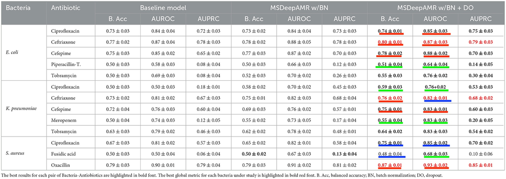

As can be seen here, my final model outperformed some of the bacteria-antibiotic pairs and showed similar performance with quite some of the others. This is quite astonishing considering the model here was trained on a much larger set of bacteria-antibiotic pairs while the model in the paper was specifically build and trained on this specific subset of bacteria-antibiotic pairs. Furthermore, here the hyperparameter testing and model complexity tested was quite limited.

However, to really understand the differences in performance it would be necessary to train and evaluate both models on the exact same split and training procedure.

16. *X. A. López-Cortés, J. M. Manríquez-Troncoso, R. Hernández-García, and D. Peralta, “MSDeepAMR: antimicrobial resistance prediction based on deep neural networks and transfer learning,” Front. Microbiol., vol. 15, p. 1361795, Apr. 2024, doi: 10.3389/fmicb.2024.1361795.*

# Conclusions and Future Work

## Summary

This notebook implements training and evaluation for antimicrobial resistance (AMR) prediction. The different model architectures benefited from different learning rates. While for the MLP the highest tested learning rate seemed most promising, the CNN had the best performance with the lowest tested learning rate. Training was time consuming, but could probably be reduced significantly by using better hardware. Inference, on the other hand, is very fast, especially considering that in practice inference is performed on one or a few mass spectrometers at a time.

Overall, the best model presented here strongly outperforms the baseline and shows performance comparable to state-of-the-art models for this task. This suggests that the methods used here are a valid starting point for further optimization and potentially the construction of the first baseline model for antimicrobial resistance prediction based on mass spectrometry data. There are many other data sets that could be used to further improve performance.

## Recommended course of action

The model presented here can be used as an antibiotic recommender, giving the physician insight into potential antibiotic resistance. When a patient with a bacterial infection enters a doctor's office, the doctor could perform a mass spectrometry of the bacteria and get the predicted antibiotic resistances within minutes. These prediction probabilities can be used to help decide which antibiotic to prescribe to the patient.

Despite the already promising performance demonstrated here, there seems to be much more potential, suggesting the implementation of further training and optimization.

## Pitfalls and Limitations

It is definitely not recommended to use the model presented here for predicting resistance to the antibiotics mupirocin and fosfomycin. Both models showed very poor performance. In general, it is recommended to consider the overall accuracy of each antibiotic when evaluating a new prediction. The certainty of a prediction can vary greatly between individual antibiotics.

Another limitation is that the output probabilities on which the decision is based do not directly reflect confidence and certainty, which may be misleading to physicians.

## Future Work

1. **Overparameterized model:** Another interesting thing to consider is to go in the other direction and build a model with many more neurons than the input dimensions. Such models have shown good results in the past, especially with noisy data, which is the case here. <sup>17</sup>
2. **Autoencoder with Bayesian neural networks:** Quantifying confidence is very important for medical applications, and again it is important that the probabilities of the model output are reliable. Bayesian neural networks (BNN) are one approach to quantifying confidence and uncertainty using the Bayes theorem. However, they are more computationally expensive and do not perform as well on large datasets.<sup>18</sup> Therefore, I would suggest to first train an autoencoder that reduces the dimensionality and finds a denser representation. As shown in the beginning, especially in the higher frequency bins, many values are close to zero, suggesting that there could be a denser representation of the data. This reduced representation could be used as input to the BNN, which could be advantageous since it reduces complexity.
3. **Lime:** Explainability is very important in medicine, so it may be interesting to use Lime to investigate which frequency bins the model used to make the decision for a particular resistance prediction. It may be that the relevant frequency bins are very different for different antibiotics.

## Discussion

AUROC and validation loss were not computed during training to save time. However, it would have been nice to collect AUROC and validation loss values during training to get a more detailed view of how training progresses with epochs.

It would have been interesting to test larger learning rates for the MLP, since the best MLP model used the highest tested learning rate, and smaller learning rates for the CNN, since the best performing CNN used the smallest tested learning rate.

The random forest baseline would definitely have benefited from some hyperparameter tuning, as the default option heavily overfits the training data, sometimes making it worse than the baseline.

Due to computational and time constraints, the complexity of the CNN model has been reduced. However, residual connections are particularly relevant in deep neural networks. Due to the reduction in layers and complexity of the CNN model, the architecture is no longer very deep, which raises the question of whether it is even necessary to use residual connections in this case. Since each residual block has only one layer, it is doubtful whether the residual connections add any benefit at all.

17. *P. Nakkiran, G. Kaplun, Y. Bansal, T. Yang, B. Barak, and I. Sutskever, “Deep Double Descent: Where Bigger Models and More Data Hurt,” 2019, arXiv. doi: 10.48550/ARXIV.1912.02292.*
18. *K. Bykov et al., “Explaining Bayesian Neural Networks,” 2021, arXiv. doi: 10.48550/ARXIV.2108.10346.*